# homework1

Collin

10/7/2020

### Q1:

*There are a number of seismic recordings from earthquakes and from mining explosions in the R package “astsa”. All of the data are in the dataframe “eqexp”, but two specific recordings are in “EQ5” and “EX6”, the fifth earthquake and the sixth explosion, respectively. The data represent two phases or arrivals along the surface, denoted by P (t = 1,…, 1024) and S (t = 1025,…, 2048), at a seismic recording station. The recording instruments are in Scandinavia and monitor a Russian nuclear testing site. The general problem of interest is in distinguishing between these waveforms in order to maintain a comprehensive nuclear test ban treaty. To compare the earthquake and explosion signals,*

**(a)** *Plot the two series separately in a multifigure plot with two rows and one column.*

```
## 'data.frame':    2048 obs. of  17 variables:
##  $ EQ1: num  0.000818 0.033801 0.016628 0.004634 -0.036527 ...
##  $ EQ2: num  -0.208 0.0303 0.099 0.2034 0.5408 ...
##  $ EQ3: num  -0.021 -0.042 -0.0682 -0.0679 -0.0345 ...
##  $ EQ4: num  -0.0643 -0.0162 -0.0859 -0.0988 -0.0406 ...
##  $ EQ5: num  0.1347 0.087 0.1162 0.1134 0.0488 ...
##  $ EQ6: num  0.0509 0.077 0.0822 0.0588 0.0137 ...
##  $ EQ7: num  -0.0193 -0.02 -0.0115 -0.0259 -0.0261 ...
##  $ EQ8: num  -0.0219 -0.2527 -0.1716 -0.144 -0.3197 ...
##  $ EX1: num  0.04102 0.03004 0.02373 0.0129 0.00261 ...
##  $ EX2: num  0.0426 0.0264 0.0258 0.0337 0.0149 ...
##  $ EX3: num  -0.00805 -0.00192 -0.01116 -0.0183 -0.01309 ...
##  $ EX4: num  -0.073 -0.0947 -0.1144 -0.0908 -0.031 ...
##  $ EX5: num  -0.1106 -0.0982 -0.0781 -0.0642 -0.0482 ...
##  $ EX6: num  -0.02724 -0.00959 -0.03337 -0.00614 -0.01189 ...
##  $ EX7: num  -0.0563 -0.0851 -0.1113 -0.1039 -0.0826 ...
##  $ EX8: num  0.201 0.242 0.307 0.323 0.209 ...
##  $ NZ : num  0.3628 0.3382 0.0147 -0.3693 -0.3834 ...
```

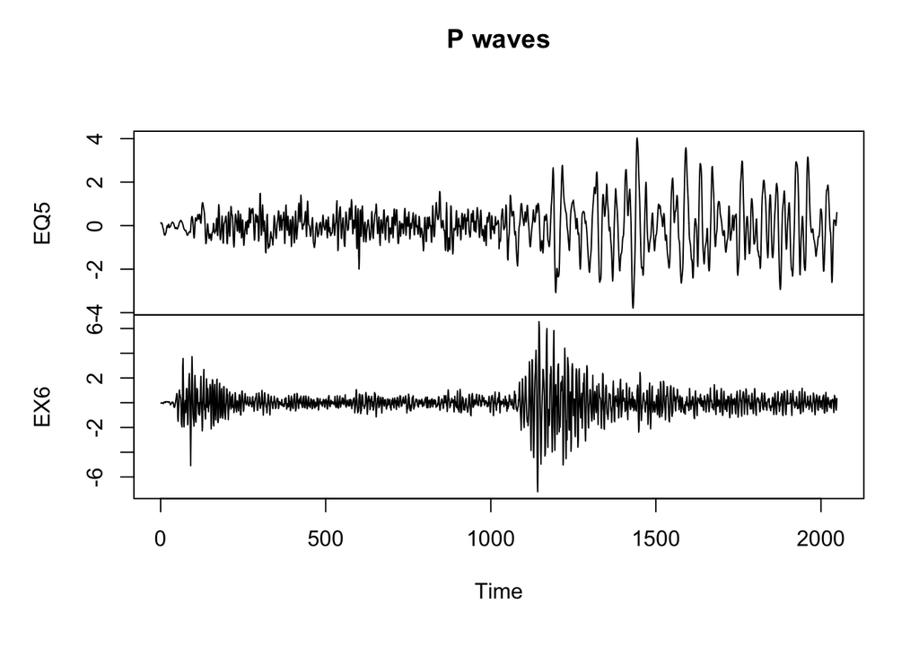

**(b)** *Plot the two series on the same graph using different colors or different line types.*

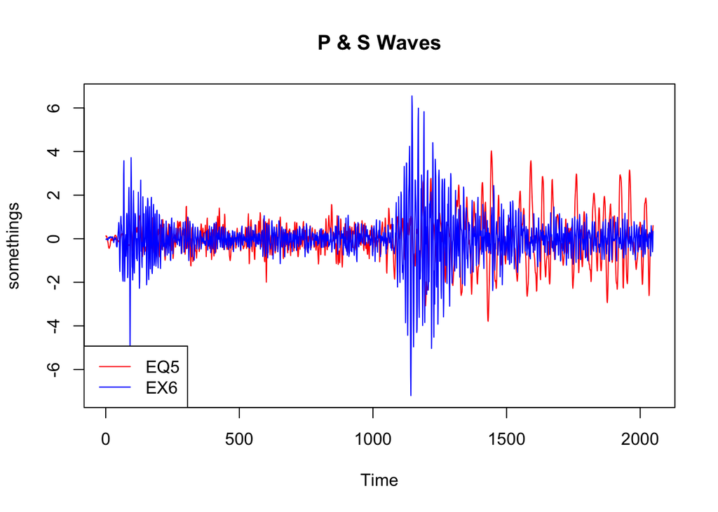

**(c)** *Would you treat the earthquake and explosion series as stationary or non-stationary? Support your answer.* Let’s take a look at the acf:

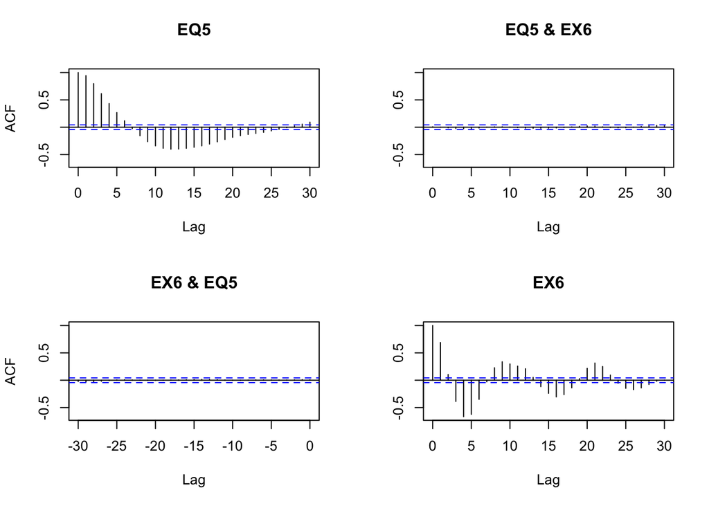

```r
acf(time_series_to_be_plotted) #Which do of these graphs do I analyze?
```

Given the noticeable seasonality in the (individual) ACF plots of the two time series, I believe the two time series are both *not* stationary

**(d)** Consider the signal plus noise model:

[figure not shown]

where

[figure not shown]

.

*Simulate and plot the following two models.* Model (i):

[figure not shown]

where

[figure not shown]

Model (ii):

[figure not shown]

where

[figure not shown]

*Compare the general appearance of the series of model (i) and (ii) with the earthquake series and the explosion series.*

model i:

```r
#model 1
s_fun1 = function(t) ifelse(t<=125, 0, 10*exp(-(t-125)/25)*cos(2*pi*t/4))
omega_fun1 = function(t) rnorm(length(t))

t_index = 1:250
set.seed(19460614)
x1 = ts(s_fun1(t_index) + omega_fun1(t_index))

str(x1) #str function tells us the object type of the argument (x)
```

```
##  Time-Series [1:250] from 1 to 250: 0.13 -0.383 -0.192 0.515 0.441 ...
```

model ii:

```r
#model 2
s_fun2 = function(t) ifelse(t<=125, 0, 10*exp(-(t-125)/250)*cos(2*pi*t/4))
omega_fun2 = function(t) rnorm(length(t))

t_index = 1:250
set.seed(19460614)
x2 = ts(s_fun2(t_index) + omega_fun2(t_index))

str(x2) #str function tells us the object type of the argument (x)
```

```
##  Time-Series [1:250] from 1 to 250: 0.13 -0.383 -0.192 0.515 0.441 ...
```

Plotting them both:

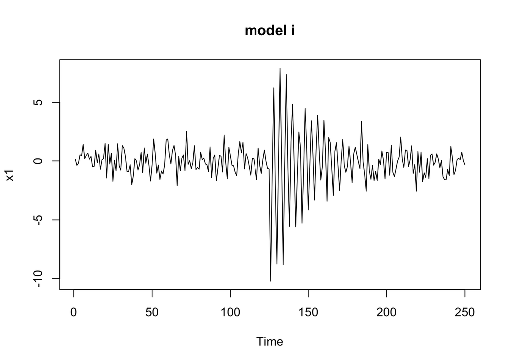

```r
plot.ts(x1, main = "model i")
```

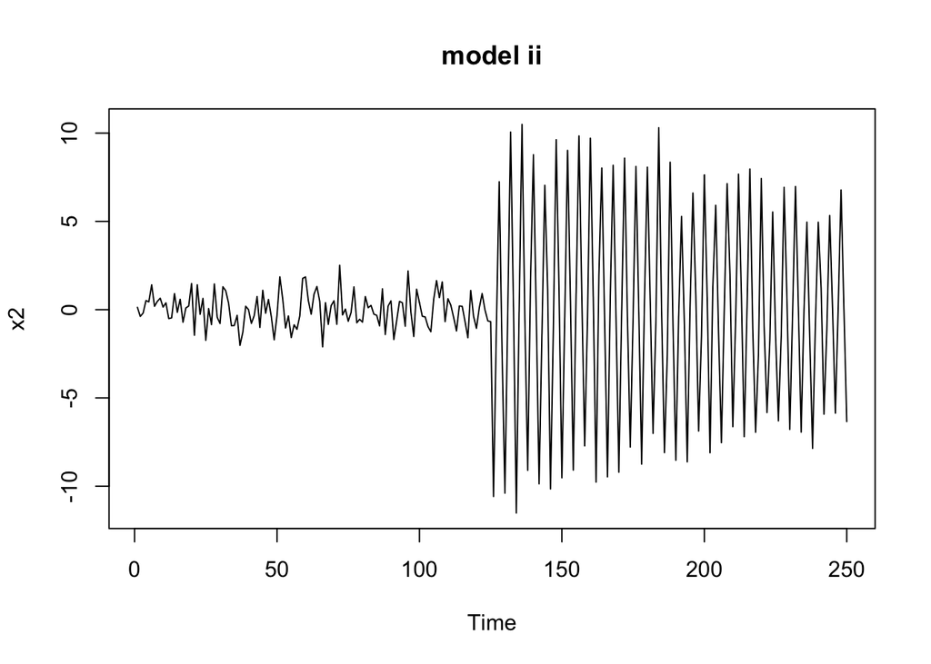

```r
plot.ts(x2, main = "model ii")
```

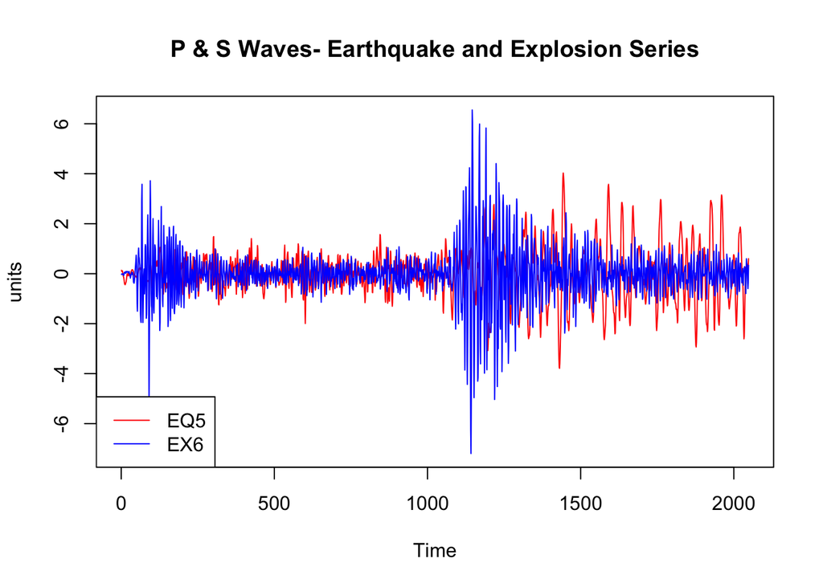

```r
plot.ts(time_series_to_be_plotted,
        plot.type="single",
        main="P & S Waves- Earthquake and Explosion Series",
        col=colors_name, #associate red with column EQ5, blue with column EX6
        ylab="units")
legend("bottomleft",
       time_series_name,
       col=colors_name,
       lty=1)
```

Notice that in the case of model i and model ii, the spike in signal occurs later in the time series (about halfway along the time series). This is contrasted against the spike seen in the Explosion Series, where a spike occurs near the beginning, and then again later, also about halfway through the series.

all the of the time series (model 1, model 2, Earthquake & Explosion) are centered about 0.